# Prediction Methods for MLE Models

Author

Affiliation

Dave Clark

Binghamton University

Published

August 18, 2024

# Predictions in MLE Models

Most MLE models are nonlinear, so their coefficients are not their marginal effects. As a result, most MLE models require a transformation of the linear prediction to generate quantities of interest. The methods outlined here apply to most MLE applications; the immediate interest and examples here use binary response models. These slides will form a foundation for prediction in other types of models we encounter.

## Binary response models

Probit and logit coefficients **are** directly interpretable in the senses that

- We can interpret direction.
- We can interpret statistical difference from zero.
- We can say the largest marginal effect of $x \approx 0.4\cdot\widehat{\beta}$ for the probit model.
- We can say the largest marginal effect of $x \approx 0.25\cdot\widehat{\beta}$ for the logit model.
- We can say that $exp(\widehat{\beta_k})-1$ is the percentage change in the odds that $y=1$, for the logit model.

It’s still the case that we often want other **quantities of interest** like probabilities, and that requires the straightforward transformations of the linear prediction, $F(x_i\widehat{\beta})$.

Let’s look briefly at the intuition of the “maximum marginal effect” in the logit model.

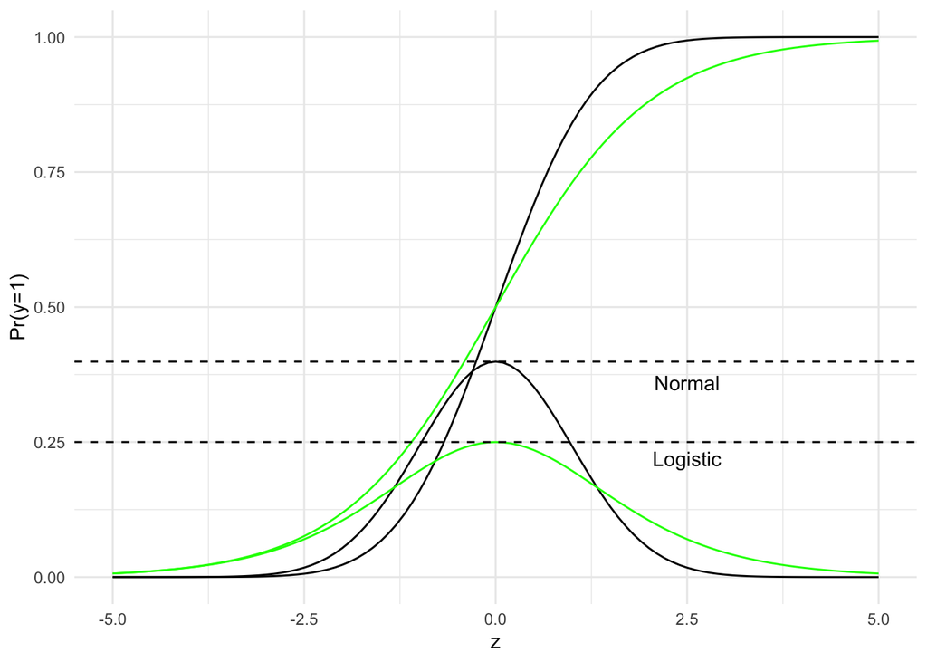

```r
z <- seq(-5,5,.1)
ncdf <- pnorm(z)
npdf <- dnorm(z)
lcdf <- plogis(z)
lpdf <- dlogis(z)

df <- data.frame(ncdf=ncdf, npdf=npdf, lcdf=lcdf, lpdf=lpdf, z=z)

ggplot(df, aes(x=z, y=ncdf), color="black") +
  geom_line() +
  geom_line(aes(x=z, y=lcdf), color="green") +
  geom_line(aes(x=z, y=npdf), color="black") +
  geom_line(aes(x=z, y=lpdf), color="green") +
  geom_hline(yintercept = .3989, linetype="dashed") +
  geom_hline(yintercept = .25, linetype="dashed") +
  labs(x="z", y="Pr(y=1)") +
  theme_minimal() +
  annotate("text", x = 2.5, y = .36, label = "Normal", color = "black") +
  annotate("text", x = 2.5, y = .22, label = "Logistic", color = "black")
```

The highest points on the PDFs indicate the maximum marginal effect of $x$ on $Pr(y=1)$ in the logit and probit models.

# Approaches to prediction

It’s important to note that these approaches and most of the technique described in these slides the same in most other MLE models and in the linear OLS model.

- **At-Means Predictions** - set variables to means/medians/modes, vary $x$ of interest, generate effect.
- **Average Effects** - set $x$ of interest to value of interest leaving all other variables at real values, then predict, average, then repeat at next value of interest.

## At-Means Predictions

At-means predictions are what they sound like - effects with independent variables set at central tendencies. These are sometimes called “adjusted predictions.”

- estimate model.
- create out of sample data.
- vary $x$ of interest; set all other $x$ variables to appropriate central tendencies - hence the “at Means.”
- generate QIs in out of sample data.

## Average Effects

Average Marginal Effects are in-sample but create a counterfactual for a variable of interest, assuming the entire sample looks like that case.

For instance, suppose a model of wages with covariates for education and gender. We might ask the question *what would the predictions look like if the entire sample were male, but otherwise looked as it does?* Alternatively, *what would the predictions look like if the entire sample were female, but all other variables the same as they appear in the estimation data?*

To answer these, we’d change the gender variable to *male*, generate $x{\widehat{\beta}}$ for the entire sample, and take the average, then repeat with the gender variable set to *female*.

To generate Average Effects,

- estimate model.
- in estimation data, set variable of interest to a particular value for the entire estimation sample.
- generate QIs (expected values, standard errors).
- take average of QIs, and save.
- repeat for all values of variable of interest, and plot.

# Methods for Quantities of Interest

Again, these are the same as in the linear model:

- direct computation - generate $F(x\widehat{\beta})$ for interesting values of $x$ (either as At-Means or Average Effects).
- simulation of $\widehat{\beta}$
- simulation of QI.

## At-means predictions (logit)

Here’s an example of at-means predictions for a logit model of the democratic peace. FIrst, let’s look at the model estimates:

```r
dp <- read_dta("/Users/dave/Documents/teaching/501/2023/slides/L7_limiteddv/code/dp.dta")

m1 <-glm(dispute ~ border+deml+caprat+ally, family=binomial(link="logit"), data=dp )

stargazer(m1, type="html",  single.row=TRUE, header=FALSE, digits=3,  omit.stat=c("LL","ser"),  star.cutoffs=c(0.05,0.01,0.001),    dep.var.caption="Dependent Variable: Dispute", dep.var.labels.include=FALSE,  covariate.labels=c("Shared Border", "Democracy", "Capabilities Ratio", "Allies"),  notes=c("Standard errors in parentheses", "Significance levels:  *** p<0.001, ** p<0.01, * p<0.05"), notes.append = FALSE,  align=TRUE,  font.size="small")
```

|  | Dependent Variable: Dispute |
| --- | --- |
| Shared Border | 1.221*** (0.078) |
| Democracy | -0.071*** (0.007) |
| Capabilities Ratio | -0.003*** (0.0004) |
| Allies | -0.806*** (0.080) |
| Constant | -3.492*** (0.075) |
| Observations | 20,990 |
| Akaike Inf. Crit. | 7,011.947 |
| *Note:* | Standard errors in parentheses |
|  | Significance levels: *** p<0.001, ** p<0.01, * p<0.05 |

As with any nonlinear model, we need to compute a linear prediction, $x\widehat{\beta}$, and then transform that to a probability. For at-means predictions, we’ll vary democracy across its range, holding the remaining variables at appropriate central tendency (e.g, mode for dummy variables, median for categorical or skewed variables, etc.) Take a look at the code:

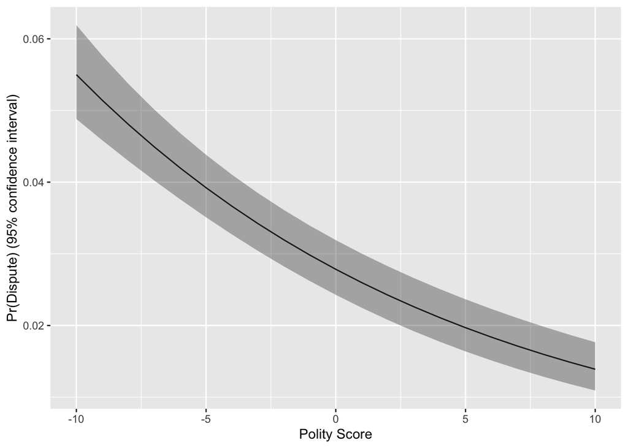

```r
dp <- read_dta("/Users/dave/Documents/teaching/501/2023/slides/L7_limiteddv/code/dp.dta")

m1 <-glm(dispute ~ border+deml+caprat+ally, family=binomial(link="logit"), data=dp )
logitpreds <- predict(m1, type="response")

m2 <-glm(dispute ~ border+deml+caprat+ally, family=binomial(link="probit"), data=dp )

#new data frame for MEM prediction
mem <- data.frame(deml= c(seq(-10,10,1)),
                  border=0, caprat=median(dp$caprat), ally=0)

# type="link" produces the linear predictions; transform by hand below w/EPT
mem  <-data.frame(mem, predict(m1, type="link", newdata=mem, se=TRUE))

mem <- cbind(mem,lb=plogis(mem$fit-1.96*mem$se.fit),
             ub=plogis(mem$fit+1.96*mem$se.fit),
             p=plogis(mem$fit))

ggplot(mem, aes(x=deml, y=p)) +
  geom_line() +
  geom_ribbon(data=mem, aes(x=deml, ymin=lb, ymax=ub),fill = "grey30", alpha = .4, ) +
  labs(x="Polity Score", y="Pr(Dispute) (95% confidence interval)")
```

## Average effects (logit)

Average effects are often a better choice because they represent the data more completely than central tendency can (in the at-mean effects). Here are average effects (using the logit estimates) across the range of polity, and for pairs of states that share borders and those that do not.

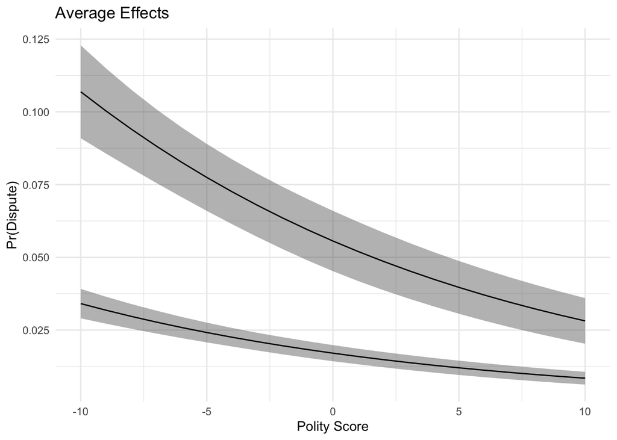

```r
#avg effects

#identify the estimation sample
dp$used <- TRUE
dp$used[na.action(m1)] <- FALSE
dpesample <- dp %>%  filter(used=="TRUE")

polity <- 0
medxbd0 <- 0
ubxbd0 <- 0
lbxbd0 <- 0
# medse <- 0
# medxbd1 <- 0
# ubxbd1 <- 0
# lbxbd1 <- 0

for(i in seq(1,21,1)){
  dpesample$border<- 0
  dpesample$deml <- i-11
  polity[i] <- i-11
  allpreds <- data.frame(predict(m1, type= "response", se.fit=TRUE, newdata = dpesample))
  medxbd0[i] <- median(allpreds$fit, na.rm=TRUE)
  ubxbd0[i] <- median(allpreds$fit, na.rm=TRUE)+1.96*(median(allpreds$se.fit, na.rm=TRUE))
  lbxbd0[i] <- median(allpreds$fit, na.rm=TRUE)-1.96*(median(allpreds$se.fit, na.rm=TRUE))
}

noborder <- data.frame(polity, medxbd0, ubxbd0, lbxbd0)

for(i in seq(1,21,1)){
  dpesample$border<- 1
  dpesample$deml <- i-11
  polity[i] <- i-11
  allpreds <- data.frame(predict(m1, type= "response", se.fit=TRUE, newdata = dpesample))
  medxbd0[i] <- median(allpreds$fit, na.rm=TRUE)
  ubxbd0[i] <- median(allpreds$fit, na.rm=TRUE)+1.96*(median(allpreds$se.fit, na.rm=TRUE))
  lbxbd0[i] <- median(allpreds$fit, na.rm=TRUE)-1.96*(median(allpreds$se.fit, na.rm=TRUE))
}

border <- data.frame(polity, medxbd0, ubxbd0, lbxbd0)



ggplot() +
  geom_ribbon(data=noborder, aes(x=polity, ymin=lbxbd0, ymax=ubxbd0),fill = "grey30", alpha = .4, ) +
  geom_line(data=noborder, aes(x=polity, y=medxbd0))+
  geom_ribbon(data=border, aes(x=polity, ymin=lbxbd0, ymax=ubxbd0),fill = "grey30", alpha = .4, ) +
  geom_line(data=border, aes(x=polity, y=medxbd0))+
  labs ( colour = NULL, x = "Polity Score", y =  "Pr(Dispute)" )+
  theme_minimal()+
  ggtitle("Average Effects")
```

## Simulation

Simulation is an especially good approach for nonlinear models:

- estimate the model.
- $m$ times (say, 1000 times), simulate the distribution of $\widehat{\beta}$.
- generate the $m$ linear predictions, $x\widehat{\beta}$.
- transform by the appropriate link function (logistic, standard normal CDF).
- identify the 2.5, 50, and 97.5 percentiles.
- plot against $x$.

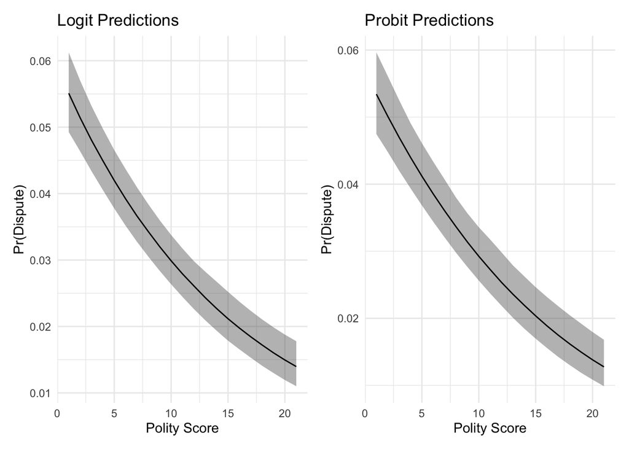

```r
#draws from multivariate normal using logit model estimates
simL <- data.frame(MASS::mvrnorm(1000, coef(m1), vcov(m1)))
#draws from multivariate normal using probit model estimates
simP <- data.frame(MASS::mvrnorm(1000, coef(m2), vcov(m2)))

#Logit predictions
logitprobs <- data.frame(dem= numeric(0) , lb=numeric(0), med= numeric(0), ub=numeric(0))
for (i in seq(1,21,1)) {
simpreds <- quantile(simL$X.Intercept.+ simL$border*0+simL$deml*(i-11)+simL$caprat*median(dp$caprat)+simL$ally*0, probs=c(.025, .5, .975))
logitprobs[i,] <- data.frame(dem=i, lb=plogis(simpreds[1]), med=plogis(simpreds[2]), ub=plogis(simpreds[3]))
}

#Probit predictions
probitprobs <- data.frame(dem= numeric(0) , lb=numeric(0), med= numeric(0), ub=numeric(0))
for (i in seq(1,21,1)) {
simpreds <- quantile(simP$X.Intercept.+ simP$border*0+simP$deml*(i-11)+simP$caprat*median(dp$caprat)+simP$ally*0, probs=c(.025, .5, .975))
probitprobs[i,] <- data.frame(dem=i, lb=pnorm(simpreds[1]), med=pnorm(simpreds[2]), ub=pnorm(simpreds[3]))
}

logit <- ggplot() +
  geom_ribbon(data=logitprobs, aes(x=dem, ymin=lb, ymax=ub),fill = "grey30", alpha = .4, ) +
  geom_line(data=logitprobs, aes(x=dem, y=med))+
  labs ( colour = NULL, x = "Polity Score", y =  "Pr(Dispute)" )+
  theme_minimal()+
  ggtitle("Logit Predictions")

probit <- ggplot() +
  geom_ribbon(data=probitprobs, aes(x=dem, ymin=lb, ymax=ub),fill = "grey30", alpha = .4, ) +
  geom_line(data=probitprobs, aes(x=dem, y=med))+
  labs ( colour = NULL, x = "Polity Score", y =  "Pr(Dispute)" )+
  theme_minimal()+
  ggtitle("Probit Predictions")

logit+probit
```

## Simulating combinations of binary variables

Let’s look at the differences among the four combinations of the binary variables, border and ally.

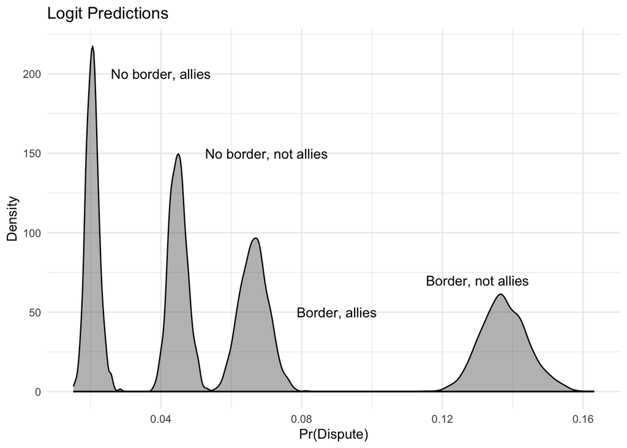

```r
## simulating for binary combinations ----

m1 <-glm(dispute ~ border+deml+caprat+ally, family=binomial(link="logit"), data=dp )

#draws from multivariate normal using logit model estimates
simL <- data.frame(MASS::mvrnorm(1000, coef(m1), vcov(m1)))


logitprobs <- data.frame(b0a0= numeric(0) , b1a0=numeric(0), b0a1= numeric(0), b1a1=numeric(0))

  b0a0 <- plogis(simL$X.Intercept.+ simL$border*0+simL$deml*-7+simL$caprat*median(dp$caprat)+simL$ally*0)
b1a0 <- plogis(simL$X.Intercept.+ simL$border*1+simL$deml*-7+simL$caprat*median(dp$caprat)+simL$ally*0)
b0a1 <- plogis(simL$X.Intercept.+ simL$border*0+simL$deml*-7+simL$caprat*median(dp$caprat)+simL$ally*1)
b1a1 <- plogis(simL$X.Intercept.+ simL$border*1+simL$deml*-7+simL$caprat*median(dp$caprat)+simL$ally*1)

logitprobs <- data.frame(b0a0, b1a0, b0a1, b1a1)

ggplot() +
  geom_density(data=logitprobs, aes(x=b0a0), fill="grey30", alpha = .4, ) +
  geom_density(data=logitprobs, aes(x=b1a0), fill="grey30", alpha = .4, ) +
  geom_density(data=logitprobs, aes(x=b0a1), fill="grey30", alpha = .4, ) +
  geom_density(data=logitprobs, aes(x=b1a1), fill="grey30", alpha = .4, ) +
  labs ( colour = NULL, x = "Pr(Dispute)", y =  "Density" ) +
  theme_minimal()+
  annotate("text", x = .07, y = 150, label = "No border, not allies", color = "black") +
  annotate("text", x = .13, y = 70, label = "Border, not allies", color = "black") +
  annotate("text", x = .04, y = 200, label = "No border, allies", color = "black") +
  annotate("text", x = .09, y = 50, label = "Border, allies", color = "black") +
  ggtitle("Logit Predictions")
```

# Uncertainty

So far, we hve focused on generating a predicted value from the model. Let’s think about generating measures of uncertainty for those predicted values.

This section examines ways to compute standard errors, and ways to use those to compute confidence intervals.

## ML Standard Errors of Linear Predictions

One commonly used measure of uncertainty is the standard error of the linear prediction, $X\widehat{\beta}$.

Consider the linear prediction

$$X \widehat{\beta}$$

under maximum likelihood theory:

$$var(X \widehat{\beta}) = \mathbf{X V X'}$$

an $N x N$ matrix, where $V$ is the var-cov matrix of ${\widehat{\beta}}$. The main diagonal contains the variances of the $N$ predictions. The standard errors are:

$$se(X \widehat{\beta}) = \sqrt{diag(\mathbf{X V X'})}$$

which is an $N x 1$ vector. So now we have a column vector of standard errors for the linear prediction, $X\widehat{\beta}$. Like the linear predictions, these are *not* transformed into probabilities, so when we compute confidence intervals, we need to map the upper and lower bounds onto the probability space.

$$F(X \widehat{\beta} - c*s.e.) \leq F(X \widehat{\beta}) \leq F(X \widehat{\beta} + c* s.e.)$$

## Delta Method standard errors

The maximum likelihood method is appropriate for monotonic functions of $X \widehat{\beta}$, e.g. logit, probit. In other models (e.g., multinomial logit), the function is not monotonic in $X \widehat{\beta}$ so we use the Delta Method - this creates a linear approximation of the function. Greene (2012) (693ff) gives this as a general derivation of the variance:

$$Var[F(X \widehat{\beta})] = f(\mathbf{x'\widehat{\beta}})^2 \mathbf{x' V x}$$

where this would generate variances for whatever $F(X \widehat{\beta})$ is, perhaps a predicted probability.

### Delta method standard errors for Logit

For the logit, the delta standard errors are given by:

$$F(X \widehat{\beta}) * (1-F(X \widehat{\beta}) * \mathbf(X V X')$$

$$= f(X \widehat{\beta}) * \mathbf{\sqrt{X V X'}}$$

or

$$p * (1-p) * stdp$$

where $stdp$ is the standard error of the linear prediction.

## SEs of Predictions for linear combinations

A common circumstance that requires joint hypothesis tests is the case of polynomials (which are themselves interactions):

$$y = \widehat{\beta}_0 + \widehat{\beta}_1 x_1 + \widehat{\beta}_2 x_{1}^2 + \varepsilon$$

The question is whether $\widehat{\beta}_1 = \widehat{\beta}_2 = 0$ - the marginal effect is:

$$\widehat{\beta}_1 + 2 \widehat{\beta}_2x_1$$

and requires the standard error for $\widehat{\beta}_1+\widehat{\beta}_2$, which is:

$$\sqrt{var(\widehat{\beta}_1) + 4x_{1}^{2}var(\widehat{\beta}_2) + 4x_1 cov(\widehat{\beta}_1, \widehat{\beta}_2) }$$

## CIs - End Point Transformation

Generate upper and lower bounds using either ML or Delta standard errors, such that

$$F(X \widehat{\beta} - c*s.e.) \leq F(X \widehat{\beta}) \leq F(X \widehat{\beta} + c* s.e.)$$

- estimate the model, generate the linear prediction, and the standard error of the linear prediction using the either ML or Delta.
- generate linear boundary predictions, $x{\widehat{\beta}} \pm c * \text{st. err.}$ where $c$ is a critical value on the normal, eg. $z=1.96$.
- transform the linear prediction and the upper and lower boundary predictions by $F(\cdot)$.
- With ML standard errors, EPT boundaries will obey distributional boundaries (ie, won’t fall outside 0-1 interval for probabilities); the linear end point predictions are symmetric, though they will not be symmetric in nonlinear models.
- With delta standard errors, bounds may not obey distributional boundaries.

## Simulating confidence intervals, I

- draw a sample with replacement of size $\tilde{N}$ from the estimation sample.
- estimate the model parameters in that bootstrap sample.
- using the bootstrap estimates, generate quantities of interest (e.g. $x\widehat{\beta}$) repeat $j$ times.
- collect all these bootstrap QIs and use either percentiles or standard deviations to measure uncertainty.

## Uncertainty: Simulating confidence intervals, II

- estimate the model.
- generate a large sample distribution of parameters (e.g. using drawnorm).
- generate quantities of interest for the distribution of parameters.
- use either percentiles or standard deviations of the QI to measure uncertainty.

Back to top

## References

Greene, William H. 2012. *Econometric Analysis*. Prentice Hall.